# 2020-4-10

Li Li

2020/4/7

# **The pretreatment of features**

- When features = NaN

If let the features(NaN) = 0, there is no influence in the process of computing logscore and forecasting, but have influence to achieve prior and posterior.

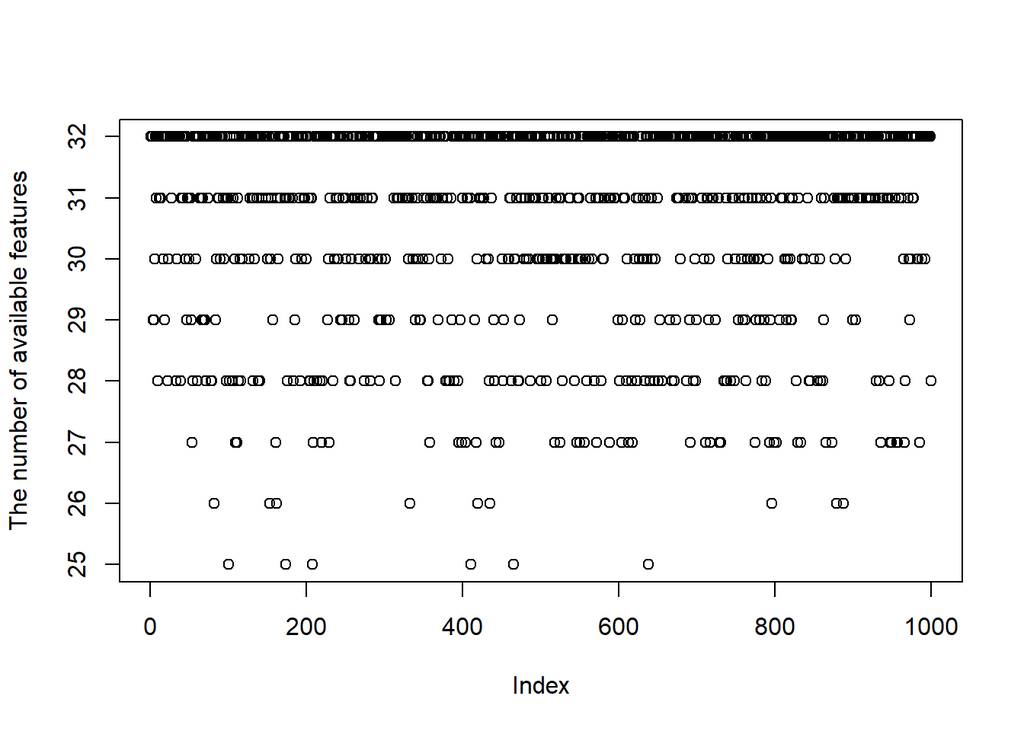

```r
load("E:/time series/R code/febama/data/historical_lpd_feature_yearly.RData")

# delete the features with NaN
feature_clean <- function(lpd_feature){
  for (i in 1:length(lpd_feature)) {
    ind <- which(is.nan(lpd_feature[[i]]$feat), arr.ind = T)[,2]
    ind0 <- ind[!duplicated(ind)]
    lpd_feature[[i]]$feat <- lpd_feature[[i]]$feat[, -ind0]
  }
  return(lpd_feature)
}

lpd_feature_yearly0 <- feature_clean(lpd_feature_yearly)

f <- c()
for (i in 1:1000) {
  f <- c(f, dim(lpd_feature_yearly0[[i]]$feat)[2])
}
plot(f, ylab = "The number of available features")
```

```r
# The features that may be deleted
ind0 <- c()
for (i in 1:1000) {
  ind <- which(is.nan(lpd_feature_yearly[[i]]$feat), arr.ind = T)[,2]
  ind0 <- c(ind0, ind[!duplicated(ind)])
}
delete_fea <- ind0[!duplicated(ind0)]
lpd_feature_yearly[[1]]$feat[1, delete_fea]
```

```
##  [1]        NaN        NaN        NaN        NaN        NaN        NaN
##  [7]        NaN        NaN        NaN        NaN -0.3089572 -0.6531244
## [13] -0.7145497 -1.1736196 -1.0702591 -1.6476679 -1.3569009 -1.2924591
## [19]  4.0578200 -3.1870826
```

**For each time series, delete the feature that has a NaN value respectively**

# **Forecasting**

```r
## Function  forecast_results
## param: a ts data with $x, $xx
## param: model_conf
## param: intercept
## param: lpd_feature with $feat, $feat_mean, $feat_sd
## param: beta_pre, a list achieved from beta_prepare function

## return: data[[i_ts]] with $ff_feature, $err_feature

library(forecast)
require("M4metalearning")

forecast_feature_results <-function(data, model_conf, intercept = T, lpd_feature, beta_pre) {

    ...

    for (t in 1:forecast_h)
    {
      ...

      ## Update features
      if (!is.null(features_y))
      {
        #用非标准化的数据计算特征
        myts <- list(list(x = ts(y_new_nonsd, frequency = frequency)))
        myfeatures <- THA_features(myts)[[1]]$features
        myfeatures <- data.matrix(myfeatures)
        myfeatures <- myfeatures[, colnames(myfeatures) %in% colnames(features_y)]
        myfeatures_scaled = scale(t(myfeatures),
                                  center = features_y_mean, scale = features_y_sd)
      } else
      {
        myfeatures_scaled = NULL
      }

      ## Update predictive weights
      w_get <- function(beta_pre){
        myfeatures_scaled <- myfeatures_scaled[, beta_pre$features_select]
        if (intercept){
          myfeatures_scaled = cbind(1, t(myfeatures_scaled))
        }
        exp_lin = exp(myfeatures_scaled %*% beta_pre$beta_mean)
        #  避免Inf
        exp_lin[exp_lin > exp(709)] <- exp(709)
        w <- exp_lin / (1 + rowSums(exp_lin))
        w_full = cbind(w, 1 - rowSums(w))
        return(w_full)
      }
      w_full <- sapply(beta_pre,  w_get)
      w_full_mean <- rowMeans(w_full)
      w_full_mean_h <- cbind(w_full_mean_h, w_full_mean)

      ## The final pooled y
      y_pred_h = sum(cbind(ets_fore_mean, arima_fore_mean) * w_full_mean)
      y_new = c(y_new, y_pred_h)
      y_new_nonsd = c(y_new_nonsd, (y_pred_h * y_sd + y_mean))
      y_hat_matrix[1, t] <- y_pred_h * y_sd + y_mean

      ### The predictive log score
      pred_densities[t, 1] <-
        dnorm(y01_true[t], mean = ets_fore_mean, sd = ets_fore_sd)
      pred_densities[t, 2] <-
        dnorm(y01_true[t], mean = arima_fore_mean, sd = arima_fore_sd)
      lpds0 = log(sum(pred_densities[t, ] * w_full_mean))
      if(lpds0 < log(1e-323)){
        lpds0 = log(1e-323)
      }else{
        lpds0 =lpds0
      }
      lpds = lpds + lpds0
    }
    data$ff_feature <- y_hat_matrix
    colnames(w_full_mean_h) <- seq(1, forecast_h, 1)
    data$w_time_varying <- w_full_mean_h

    ### mase smape
    ...

  }
```

```
data1 <- forecast_feature_results (data, model_conf, intercept = T,
                          lpd_feature = lpd_feature_yearly0[[1000]] , beta_pre)
# > data1$ff_feature
#          [,1]     [,2]     [,3]     [,4]     [,5]     [,6]
# [1,] 1985.126 1941.003 1899.495 1861.308 1824.618 1786.952
# > data1$w_time_varying
#              1         2         3         4         5         6
# [1,] 0.5206587 0.4640201 0.4807094 0.5083619 0.5139011 0.4871044
# [2,] 0.4793413 0.5359799 0.5192906 0.4916381 0.4860989 0.5128956
# > data1$err_feature
#           lpds mase_err_h smape_err_h
# [1,] -3.087402  0.8507114     6.46618
```

# **Usage example**

- Compute log predictive density of each model and features by function “lpd_feature”.

```r
lpd_feature_3187 <- lpd_feature(M4[[3187]])
```

```
> head(lpd_feature_3187$lpd,3)
           [,1]       [,2]
[1,] -0.7325790 -0.8168236
[2,] -0.7936347 -0.7024910
[3,] -0.7709599 -0.7053068
> head(lpd_feature_3187$feat,3)
          x_acf1    x_acf10 diff1_acf1 diff1_acf10 diff2_acf1 diff2_acf10 seas_acf1    ARCH.LM
[1,] -2.08060231 -0.8426958  0.8221584  -0.6659605   0.666645  -0.5032017       NaN -0.3333333
[2,] -0.99480023 -0.8426958  0.8221584  -0.6659605   0.666645  -0.5032017       NaN -0.3333333
[3,] -0.24407366 -0.8426958  0.8221584  -0.6659605   0.666645  -0.5032017       NaN -0.3333333
     crossing_points     entropy flat_spots   arch_acf   garch_acf arch_r2 garch_r2      alpha       beta
[1,]      -0.6666667  1.61110866 -0.9428090 -1.2427045 -1.48054247     NaN      NaN  1.2910074  1.3766453
[2,]      -0.6666667  1.61110866 -0.9428090  0.7317511 -1.68813243     NaN      NaN  1.3325163  1.3100749
[3,]       1.3333333 -0.15435306 -0.2357023  2.1024010 -0.40075794     NaN      NaN  1.3755812  1.3125667
          hurst lumpiness nonlinearity      x_pacf5 diff1x_pacf5 diff2x_pacf5 seas_pacf nperiods
[1,] -2.2539053       NaN    2.2542529 -2.126588048   -1.7566029   -1.7501243       NaN      NaN
[2,] -0.8471318       NaN    0.6428845 -0.008715726    1.8773950   -1.7501243       NaN      NaN
[3,] -0.2131346       NaN    0.3794128 -0.080654410    0.5901752    0.2136182       NaN      NaN
     seasonal_period      trend      spike  linearity  curvature     e_acf1    e_acf10 seasonal_strength
[1,]             NaN -2.1994141  2.2581887  1.6404062 -1.2519896 -1.2632926 -0.8278212               NaN
[2,]             NaN -0.7338595  0.9246881  1.2048736 -1.0364691 -1.2982132 -0.8278212               NaN
[3,]             NaN -0.5284060  0.1704327  0.6744664 -0.6920035 -0.6836307 -0.8278212               NaN
     peak trough stability hw_alpha hw_beta hw_gamma unitroot_kpss unitroot_pp series_length
[1,]  NaN    NaN       NaN      NaN     NaN      NaN   -1.02542674   1.0695758    -1.4605935
[2,]  NaN    NaN       NaN      NaN     NaN      NaN   -1.24307909   0.8757665    -1.0954451
[3,]  NaN    NaN       NaN      NaN     NaN      NaN   -1.01833310   0.5559018    -0.7302967
```

- Delete the features with NaN by function “feature_clean”

The input of feature_clean is a list including multiple time series’ log predictive density and features.

```r
lpd_feature_yearly0 <- feature_clean(lpd_feature_yearly)
```

```
> head(lpd_feature_yearly0[[1000]]$lpd,3)
           [,1]       [,2]
[1,] -0.7325790 -0.8168236
[2,] -0.7936347 -0.7024910
[3,] -0.7709599 -0.7053068
> head(lpd_feature_yearly0[[1000]]$feat,3)
         x_acf1    x_acf10 diff1_acf1 diff1_acf10 diff2_acf1 diff2_acf10    ARCH.LM crossing_points
[1,] -2.0806023 -0.8426958  0.8221584  -0.6659605   0.666645  -0.5032017 -0.3333333      -0.6666667
[2,] -0.9948002 -0.8426958  0.8221584  -0.6659605   0.666645  -0.5032017 -0.3333333      -0.6666667
[3,] -0.2440737 -0.8426958  0.8221584  -0.6659605   0.666645  -0.5032017 -0.3333333       1.3333333
        entropy flat_spots   arch_acf  garch_acf    alpha     beta      hurst nonlinearity      x_pacf5
[1,]  1.6111087 -0.9428090 -1.2427045 -1.4805425 1.291007 1.376645 -2.2539053    2.2542529 -2.126588048
[2,]  1.6111087 -0.9428090  0.7317511 -1.6881324 1.332516 1.310075 -0.8471318    0.6428845 -0.008715726
[3,] -0.1543531 -0.2357023  2.1024010 -0.4007579 1.375581 1.312567 -0.2131346    0.3794128 -0.080654410
     diff1x_pacf5 diff2x_pacf5      trend     spike linearity  curvature     e_acf1    e_acf10 unitroot_kpss
[1,]   -1.7566029   -1.7501243 -2.1994141 2.2581887 1.6404062 -1.2519896 -1.2632926 -0.8278212     -1.025427
[2,]    1.8773950   -1.7501243 -0.7338595 0.9246881 1.2048736 -1.0364691 -1.2982132 -0.8278212     -1.243079
[3,]    0.5901752    0.2136182 -0.5284060 0.1704327 0.6744664 -0.6920035 -0.6836307 -0.8278212     -1.018333
     unitroot_pp series_length
[1,]   1.0695758    -1.4605935
[2,]   0.8757665    -1.0954451
[3,]   0.5559018    -0.7302967
> lpd_feature_yearly0[[1000]]$feat_mean
         x_acf1         x_acf10      diff1_acf1     diff1_acf10      diff2_acf1     diff2_acf10
   0.6582976598    0.5800998330   -0.1192354081    0.1337927235   -0.1197015902    0.1313666500
        ARCH.LM crossing_points         entropy      flat_spots        arch_acf       garch_acf
   0.1111111111    1.6666666667    0.9078982523    3.3333333333    0.3551811873    0.7292219755
          alpha            beta           hurst    nonlinearity         x_pacf5    diff1x_pacf5
   0.2514786077    0.2079265909    0.9091401008    7.1918299113    0.7255042946    0.3553620296
   diff2x_pacf5           trend           spike       linearity       curvature          e_acf1
   0.3140414878    0.9205594908    0.0003448255   -2.7482758028    0.4165217905   -0.3510724293
        e_acf10   unitroot_kpss     unitroot_pp   series_length
   0.1829321849    0.4380314235   -0.9461200947   10.0000000000
> lpd_feature_yearly0[[1000]]$feat_sd
         x_acf1         x_acf10      diff1_acf1     diff1_acf10      diff2_acf1     diff2_acf10
   0.1049897312    0.6883858284    0.1450272992    0.2009018788    0.1795582167    0.2610616228
        ARCH.LM crossing_points         entropy      flat_spots        arch_acf       garch_acf
   0.3333333333    1.0000000000    0.0571666890    1.4142135624    0.0371729233    0.2785401880
          alpha            beta           hurst    nonlinearity         x_pacf5    diff1x_pacf5
   0.3769639191    0.3116249041    0.0644216350    5.2379866967    0.1371039896    0.2023007145
   diff2x_pacf5           trend           spike       linearity       curvature          e_acf1
   0.1794395306    0.0284881237    0.0003432597    0.3793566843    0.3534819847    0.1173883114
        e_acf10   unitroot_kpss     unitroot_pp   series_length
   0.2209803129    0.0537407453    0.4759283562    2.7386127875
```

- Optimize the parameter beta to give weights to the individual forecasting methods so that their weighted linear combination has bigger log score. This process is accompanied by feature selection.
  - Sampling the parameter beta througth SGLD_VS function.

```r
l <- SGLD_VS(lpd_feature_yearly0[[1000]], logLik = log_score, gradient_logLik = gradient,
                    prior = prior,  SGLD_iter = 100, VS_iter = 100)
```

```
> t(l$I[,1:3])
     [,1] [,2] [,3] [,4] [,5] [,6] [,7] [,8] [,9] [,10] [,11] [,12] [,13] [,14] [,15] [,16] [,17] [,18]
[1,]    0    1    0    0    1    1    0    0    1     1     0     0     1     1     1     0     0     0
[2,]    0    0    1    0    0    1    0    1    0     1     1     1     1     0     0     0     1     0
[3,]    0    0    0    1    0    0    0    1    1     0     1     0     0     1     0     1     0     0
     [,19] [,20] [,21] [,22] [,23] [,24] [,25] [,26] [,27] [,28]
[1,]     0     1     1     0     0     1     0     1     0     1
[2,]     0     0     1     1     0     1     1     1     0     0
[3,]     0     0     0     0     0     1     0     1     1     1

> tail(l$B[[1]],3)
               0         2          5         6         9       10        13         14       15       20
 [99,] -1.810209 -1.580612 -0.9863436 -6.339370 1.0125594 2.432930 0.9307622 -0.3990265 4.792831 6.690588
[100,] -1.651420 -1.466940 -0.9369397 -6.260572 1.0214952 2.273019 1.1815217 -0.3986494 4.864942 6.601508
[101,] -1.667234 -1.449368 -1.0441772 -5.955529 0.8440529 2.424552 1.1257671 -0.3400894 4.827172 6.674293
               21        24        26       28
 [99,] -0.3657729 -5.610637 -4.238624 4.933544
[100,] -0.3641393 -5.598147 -4.378394 4.840150
[101,] -0.3705887 -5.750628 -4.152789 4.820188
```

- - Achieve the mean of beta and the selected features in each VS

```r
beta_pre <- beta_prepare (samples_SGLD_VS = l, num = 50)
```

```
> beta_pre[[1]]
$beta_mean
          0           2           5           6           9          10          13          14          15
-0.86366000 -1.80455526 -1.33084922 -6.03181148  0.03746227  2.01448771  1.09146369 -0.62005520  5.26819915
         20          21          24          26          28
 7.55783751 -1.43156015 -5.84077031 -3.59712466  4.78476943

$features_select
 [1]  2  5  6  9 10 13 14 15 20 21 24 26 28
```

- Forecasting with time varying weights

```r
data1 <- forecast_feature_results (data, model_conf, intercept = T,
                          lpd_feature = lpd_feature_yearly0[[1000]] , beta_pre)
```

```
# > data1$ff_feature
#          [,1]     [,2]     [,3]     [,4]     [,5]     [,6]
# [1,] 1985.126 1941.003 1899.495 1861.308 1824.618 1786.952

# > data1$w_time_varying
#              1         2         3         4         5         6
# [1,] 0.5206587 0.4640201 0.4807094 0.5083619 0.5139011 0.4871044
# [2,] 0.4793413 0.5359799 0.5192906 0.4916381 0.4860989 0.5128956

# > data1$err_feature
#           lpds mase_err_h smape_err_h
# [1,] -3.087402  0.8507114     6.46618
```

# **Some tests on SGLD_VS**

- **stepsize**
  - stepsize = 0.1, 0.01, 0.001
  - stepsize = a*(b + t)^(-gama), (gama = 0.55, a = 0.4, b = 10)

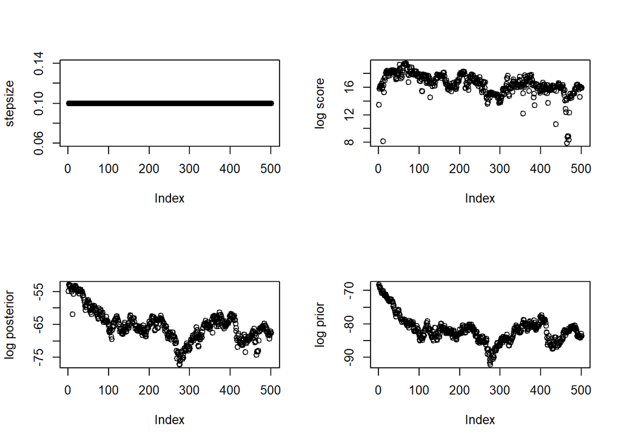

```r
setwd("E:/time series/R code/febama/data")
load("~/historical_lpd_feature_yearly.RData")

lpd_feature_yearly0 <- feature_clean(lpd_feature_yearly)

set.seed(2020-4-9)
step1 <- SGLD (data = lpd_feature_yearly0[[1]], logLik = log_score, gradient_logLik = gradient,
      prior = prior, start = rep(0,33), minibatchSize = 1,
      stepsize = 0.1, tol = 1e-5, iter = 500, samplesize = 0.5,
      features_select = seq(1,32,1), I = rep(1,32), sig = 10,
      intercept = TRUE, gama = 0.55, a = 0.4, b = 10 )
par(mfrow=c(2,2))
plot(step1$stepsize, ylab = "stepsize")
plot(step1$logscore, ylab = "log score")
plot(step1$logpost, ylab = "log posterior")
plot(log(step1$prior), ylab = "log prior")
```

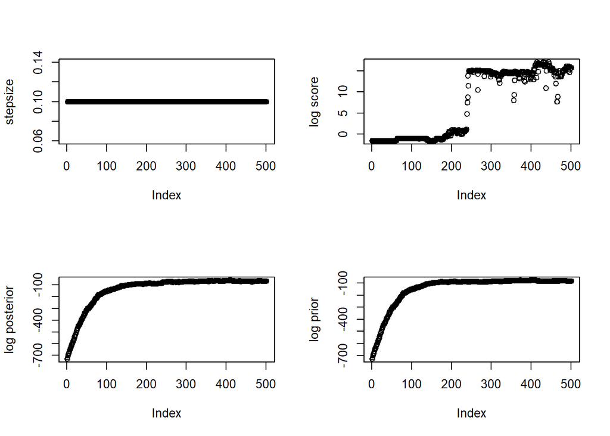

```r
set.seed(2020-4-9)
step2 <- SGLD (data = lpd_feature_yearly0[[1]], logLik = log_score, gradient_logLik = gradient,
      prior = prior, start = rep(20,33), minibatchSize = 1,
      stepsize = 0.1, tol = 1e-5, iter = 500, samplesize = 0.5,
      features_select = seq(1,32,1), I = rep(1,32), sig = 10,
      intercept = TRUE, gama = 0.55, a = 0.4, b = 10 )
par(mfrow=c(2,2))
plot(step2$stepsize, ylab = "stepsize")
plot(step2$logscore, ylab = "log score")
plot(step2$logpost, ylab = "log posterior")
plot(log(step2$prior), ylab = "log prior")
```

**stepsize = 0.1**

**log prior dominates the trace of log posterior**, because the value of prior is very small.

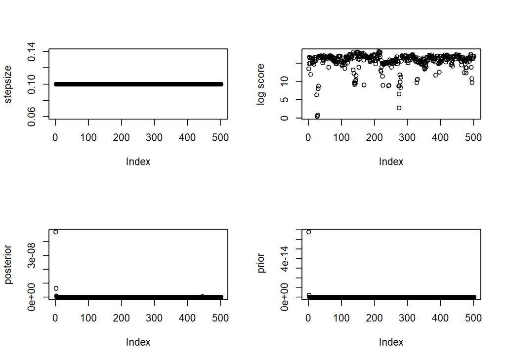

```r
set.seed(2020-4-9)
GD_2 <- SGLD (data = lpd_feature_yearly0[[1]], logLik = log_score, gradient_logLik = gradient,
      prior = prior, start = rep(0,33), minibatchSize = .1,
      stepsize = 0.1, tol = 1e-5, iter = 500, samplesize = 0.5,
      features_select = seq(1,32,1), I = rep(1,32), sig = 1,
      intercept = TRUE, gama = 0.55, a = 0.4, b = 10 )
par(mfrow=c(2,2))
plot(GD_2$stepsize, ylab = "stepsize")
plot(GD_2$logscore, ylab = "log score")
plot(exp(GD_2$logpost), ylab = "posterior")
plot(GD_2$prior, ylab = " prior")
```

**Is the prior reasonable?**

- **minibatchSize**

```r
 if(! is.null(minibatchSize)){
    minibatchSize = minibatchSize
  } else if (length(prob[,1]) <= 10){
    minibatchSize = 1
  }else {
    minibatchSize = 0.1
  }
```

- run time

```
# length of ts[[1]] is 529
# minibatchSize = 0.01
# 用户  系统  流逝
# 25.35  1.52 27.46

# minibatchSize = 0.1
# 用户  系统  流逝
# 25.42  0.05 25.55

# minibatchSize = 1
# 用户  系统  流逝
# 33.18 18.02 55.09
```

- **initial value**

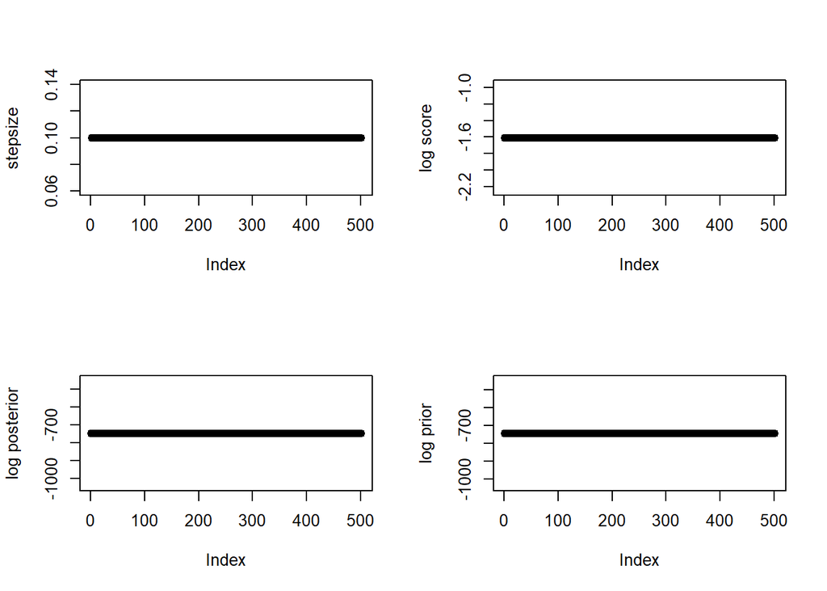

```r
set.seed(2020-4-9)
GD_2 <- SGLD (data = lpd_feature_yearly0[[1]], logLik = log_score, gradient_logLik = gradient,
      prior = prior, start = rep(100,33), minibatchSize = .1,
      stepsize = 0.1, tol = 1e-5, iter = 500, samplesize = 0.5,
      features_select = seq(1,32,1), I = rep(1,32), sig = 10,
      intercept = TRUE, gama = 0.55, a = 0.4, b = 10 )
par(mfrow=c(2,2))
plot(GD_2$stepsize, ylab = "stepsize")
plot(GD_2$logscore, ylab = "log score")
plot(GD_2$logpost, ylab = "log posterior")
plot(log(GD_2$prior), ylab = "log prior")
```

```r
head(GD_2$beta)
```

```
##                   x_acf1  x_acf10 diff1_acf1 diff1_acf10 diff2_acf1 diff2_acf10
## [1,] 100.00000 100.00000 100.0000  100.00000   100.00000  100.00000   100.00000
## [2,] 100.04047  99.50077 100.1147   99.67121    99.77589   99.55824    99.02883
## [3,]  99.92520 100.12535 100.6972  100.03683    99.51076  100.05824    99.88567
## [4,] 100.31093 100.24603 100.8711  100.02221    99.69846   99.71206    99.46246
## [5,]  99.95858 100.20693 100.7135  101.03221    99.66251   99.89765    99.30658
## [6,] 100.12818 100.26828 101.1434  101.28468   100.19526   99.93857    99.25792
##       ARCH.LM crossing_points  entropy flat_spots  arch_acf garch_acf  arch_r2
## [1,] 100.0000        100.0000 100.0000  100.00000 100.00000  100.0000 100.0000
## [2,] 100.7327        100.2497 100.2341  100.36170  99.32635  100.0488 100.1832
## [3,] 101.0396        100.5092 100.6168   99.66140  98.75749  100.6357 100.1983
## [4,] 101.2569        100.6537 100.2245   99.69157  98.58795  100.5727 100.7576
## [5,] 100.5903        100.9432 101.0045   99.79127  98.82634  100.8509 101.5408
## [6,] 100.1344        101.2434 101.1027  100.91491  99.06178  101.4698 101.6001
##      garch_r2    alpha      beta     hurst lumpiness nonlinearity   x_pacf5
```

[output cut: 20 more lines]

- **when prior = 0**

```r
prior <- function(beta, I, sig = 10){
  pri <- (
    dmvnorm(as.vector(beta), mean=matrix(0, length(beta), 1), sigma = sig*diag(length(beta)))
    # * 0.5 ^ length(I)
  )
  # avoid prior=0
  if (pri < 1e-323) {pri <- 1e-323}
  return(pri)
}
```

- **when gradient = NaN (Inf / Inf)**

```r
  ex = exp(features0 %*% beta)
  ex[ex > exp(700)] = exp(700)
```

- **the update of beta mainly depends on the white noise**

# **The performance of forecasting**

```r
l1 <- SGLD_VS(lpd_feature_yearly0[[809]], logLik = log_score, gradient_logLik = gradient, prior = prior,  SGLD_iter = 500, VS_iter = 100, minibatchSize = .1, sig = 10, stepsize = 0.1)
save(l,file = "E:/time series/R code/febama/data/data1_SGLDVS_test.RData")
```

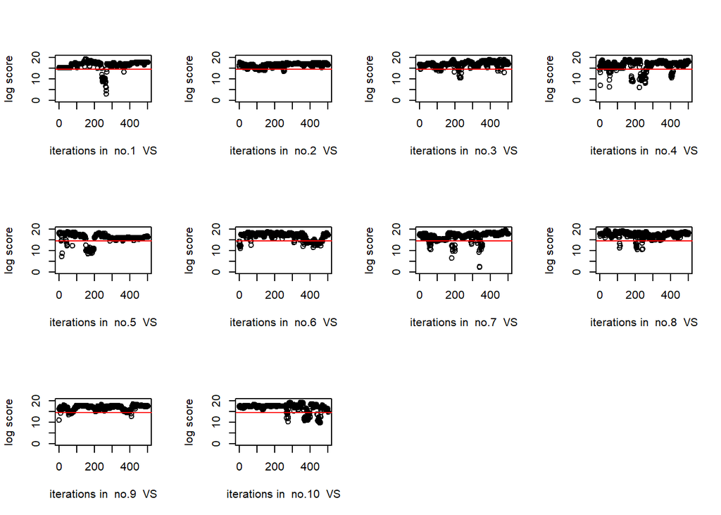

```r
load("E:/time series/R code/febama/data/data1_SGLDVS_test.RData")
# optim (no feature, L-BFGS-B)
# optim_beta(lpd_feature_yearly[[5]], features_y = NULL)
# $logscore
# [1] 14.51317
par(mfrow = c(3,4))
for (i in 1:10) {
  plot(l$result_all[[i]]$logscore, ylim = c(0,20), ylab = "log score",
       xlab = paste0('iterations in  no.', i, '  VS') )
  abline(h=14.51317, col = "2")
}

par(mfrow = c(3,4))
```

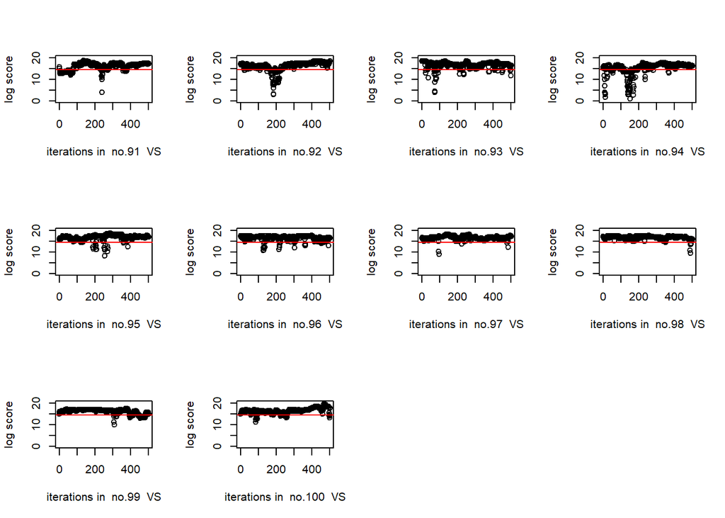

```r
for (i in 1:10) {
  plot(l$result_all[[i+90]]$logscore, ylim = c(0,20), ylab = "log score",
       xlab = paste0('iterations in  no.', i+90, '  VS') )
  abline(h=14.51317, col = "2")
}
```

```r
beta_pre <- beta_prepare (samples_SGLD_VS = l, num = 100)
data1 <- forecast_feature_results (data[[1]], model_conf, intercept = T,
                          lpd_feature = lpd_feature_yearly0[[1]] , beta_pre)
data1$ff_feature
data1$w_time_varying
data1$err_feature
```

```r
# > data1$ff_feature
#          [,1]     [,2]    [,3]     [,4]     [,5]     [,6]
# [1,] 9001.205 9269.646 9530.57 9789.192 10042.36 10292.14
# > data1$w_time_varying
#               1          2         3          4          5         6
# [1,] 0.09892623 0.05007653 0.0750736 0.08093623 0.09797849 0.1072987
# [2,] 0.90107377 0.94992347 0.9249264 0.91906377 0.90202151 0.8927013
# > data1$err_feature
#           lpds mase_err_h smape_err_h
# [1,] -21.32308   2.642592    7.754433
```

```r
load("E:/time series/R code/feature-based-bayesian-model-averaging/data/data_forecast_yearly.RData")
data_forecast[[1]]$logscore
```

```
##              log score
## Optimal pool -24.63481
## SA           -32.91990
## ETS          -54.09524
## ARIMA        -22.62739
```

```r
data_forecast[[1]]$mase_err
```

```
##                  [,1]
## Optimal pool 3.138012
## SA           4.058932
## ETS          5.661141
## ARIMA        2.363286
```

```r
data_forecast[[1]]$smape_err
```

```
##                   [,1]
## Optimal pool  9.277170
## SA           12.180785
## ETS          17.472125
## ARIMA         6.908469
```